# covid19

A dataset provided by WHO , “who_events”, it states the different events like declaration of pandemic, etc.

```r
who_events <- read.csv("who_events.csv")
who_events
```

```
##         date                             event
## 1 2020-01-30 Global health\nemergency declared
## 2 2020-02-13           China reporting\nchange
## 3 2020-03-11                Pandemic\ndeclared
```

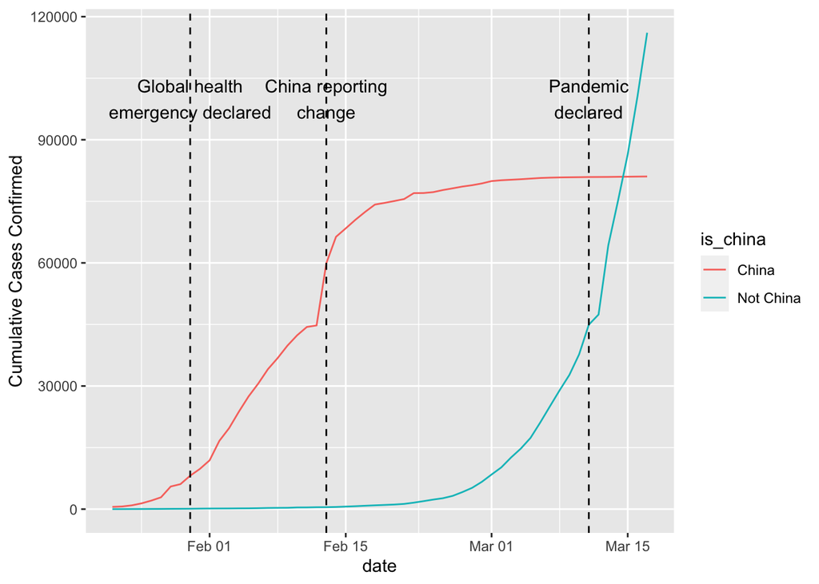

```r
who_events <-   tribble(~ date, ~ event,

"2020-01-30", "Global health\nemergency declared",
  "2020-03-11", "Pandemic\ndeclared",
  "2020-02-13", "China reporting\nchange") %>%
  mutate(date = as.Date(date))

plot_confirmed_cases_china_vs_rest_world +
geom_vline(aes(xintercept = date), data = who_events, linetype = "dashed") +

geom_text(aes(date,label = event), data = who_events, y = 1e5 )
```

SCENARIO IN CHINA AFTER 15TH FEB

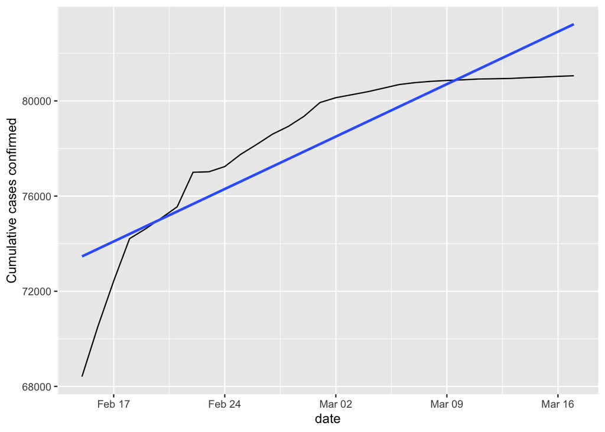

```r
cases_in_china_after_15feb <- confirmed_cases_china_vs_rest_world %>%
  filter(is_china == "China", date >= "2020-02-15")
ggplot(cases_in_china_after_15feb, aes(date, cum_cases)) +
  geom_line() +
  geom_smooth(method = "lm", se = FALSE) +
  ylab("Cumulative cases confirmed")
```

SCENARIO IN REST OF THE WORLD - NON CHINA COUNTRIES

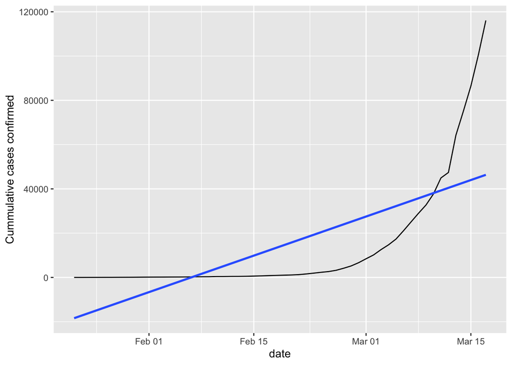

```r
not_china <- confirmed_cases_china_vs_rest_world %>%
  filter(is_china == "Not China")

non_china_plot <- ggplot(not_china, aes(date, cum_cases)) +
  geom_line() +
  geom_smooth(method = "lm", se = FALSE) +
  ylab("Cummulative cases confirmed")

non_china_plot
```

Considering the situation in rest of the world initially there was no sign of virus or but after 15th feb number of cases grew exponentially.

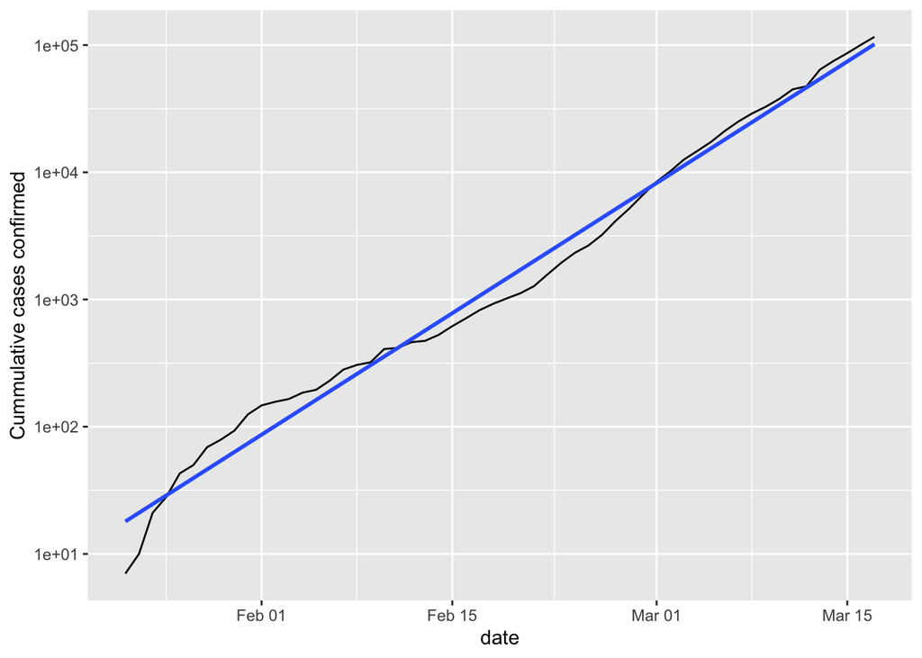

```r
non_china_plot +
    scale_y_log10()
```

It seems a negative sign , that in rest of the world number of cases are increasing at an exponential rate.It may not be necessary that all countries outside China are affected , but we can study the extent of impact over other countries from the dataset provided “confirmed cases by country”.

```r
confirmed_cases_by_country <- read_csv("confirmed_cases_by_country.csv")
confirmed_cases_by_country
```

```
## # A tibble: 13,272 x 5
##    country             province date       cases cum_cases
##    <chr>               <chr>    <date>     <dbl>     <dbl>
##  1 Afghanistan         <NA>     2020-01-22     0         0
##  2 Albania             <NA>     2020-01-22     0         0
##  3 Algeria             <NA>     2020-01-22     0         0
##  4 Andorra             <NA>     2020-01-22     0         0
##  5 Antigua and Barbuda <NA>     2020-01-22     0         0
##  6 Argentina           <NA>     2020-01-22     0         0
##  7 Armenia             <NA>     2020-01-22     0         0
##  8 Aruba               <NA>     2020-01-22     0         0
##  9 Austria             <NA>     2020-01-22     0         0
## 10 Azerbaijan          <NA>     2020-01-22     0         0
## # … with 13,262 more rows
```

```r
glimpse(confirmed_cases_by_country)
```

```
## Observations: 13,272
## Variables: 5
## $ country   <chr> "Afghanistan", "Albania", "Algeria", "Andorra", "Antigua an…
## $ province  <chr> NA, NA, NA, NA, NA, NA, NA, NA, NA, NA, NA, NA, NA, NA, NA,…
## $ date      <date> 2020-01-22, 2020-01-22, 2020-01-22, 2020-01-22, 2020-01-22…
## $ cases     <dbl> 0, 0, 0, 0, 0, 0, 0, 0, 0, 0, 0, 0, 0, 0, 0, 0, 0, 0, 0, 0,…
## $ cum_cases <dbl> 0, 0, 0, 0, 0, 0, 0, 0, 0, 0, 0, 0, 0, 0, 0, 0, 0, 0, 0, 0,…
```

```r
top_10_countries_cases <- confirmed_cases_by_country %>%
  group_by(country) %>%
  summarise(total_cases = max(cum_cases)) %>%
              top_n(10,total_cases)
            top_10_countries_cases %>%
              arrange(desc(total_cases))
```

```
## # A tibble: 10 x 2
##    country        total_cases
##    <chr>                <dbl>
##  1 Italy                31506
##  2 Iran                 16169
##  3 Spain                11748
##  4 Germany               9257
##  5 Korea, South          8320
##  6 France                7699
##  7 US                    6421
##  8 Switzerland           2700
##  9 United Kingdom        1960
## 10 Netherlands           1708
```

Top 4 hardest hit countries are Italy, Iran, Spain, Germany

TOP 7 hit countries outside china

```r
top_7_countries_cases_non_china <- read.csv("confirmed_cases_top7_outside_china.csv")
top_7_countries_cases_non_china
```

[output not shown]

[output cut: 2016 more lines]

```r
glimpse(top_7_countries_cases_non_china)
```

```
## Observations: 2,030
## Variables: 3
## $ country   <fct> "Germany", "Iran", "Italy", "Korea, South", "Spain", "US", …
## $ date      <fct> 2020-02-18, 2020-02-18, 2020-02-18, 2020-02-18, 2020-02-18,…
## $ cum_cases <int> 16, 0, 3, 31, 2, 13, 13, 13, 13, 13, 13, 13, 13, 13, 13, 13…
```

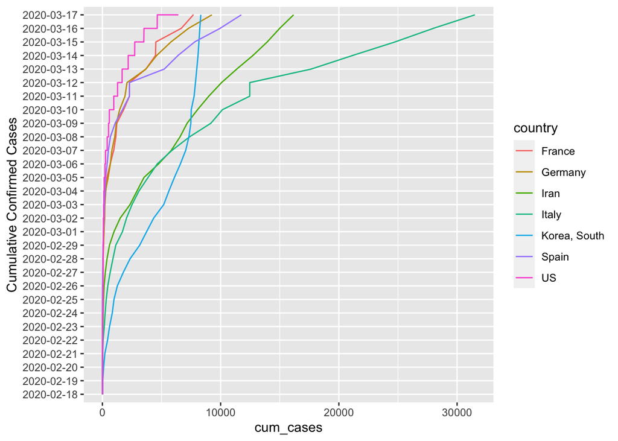

```r
ggplot(top_7_countries_cases_non_china, aes(x = cum_cases, y = date, color = country, group = country )) +
  geom_line() +

  ylab("Cumulative Confirmed Cases")
```

We can infer from this that irrespective of the fact that first breakthrough was in China, but eventually Italy was the worst effected with max cases, and there is only one country of East Asia region ( South Korea). Countries like France, Germany, Italy, Spain they are in Europe.